# VLM Wrong Predictions: attr_bridge_type [both_wrong]

**Model:** VLM vs DINOv3  
**Attribute:** attr_bridge_type [both_wrong]  
**Wrong assets:** 20 of 20 (100.0% asset-level error rate)

Asset 48112 1 image

Predicted: VLM: Beam | DINOv3: Beam (conf: N/A)

Actual: Truss

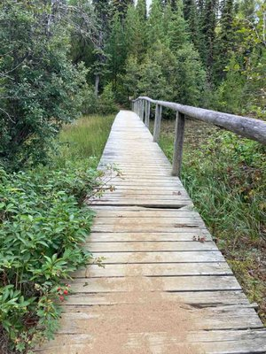

73499__AST_EX_20240913_141001.jpeg

Asset 56533 2 images

Predicted: VLM: Truss | DINOv3: Truss (conf: N/A)

Actual: Beam

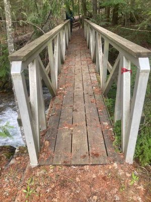

41111__AST_EX_20220512_124053.jpeg

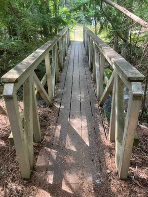

72330__AST_EX_20240811_112412.jpeg

Asset 64126 2 images

Predicted: VLM: Beam | DINOv3: Beam (conf: N/A)

Actual: Fallen Tree

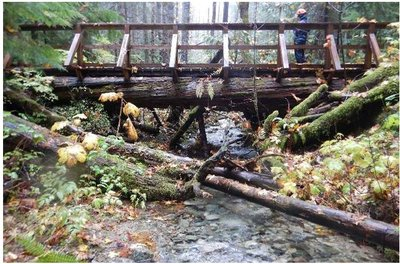

85871__asset64126-2.jpg

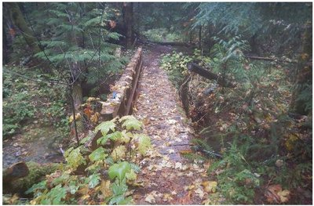

85872__asset64126.jpg

Asset 65423 1 image

Predicted: VLM: Truss | DINOv3: Truss (conf: N/A)

Actual: Beam

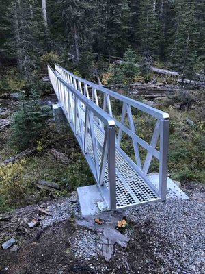

22109__AST_EX_20210916_081727.jpeg

Asset 65788 9 images

Predicted: VLM: Truss | DINOv3: Truss (conf: N/A)

Actual: Beam

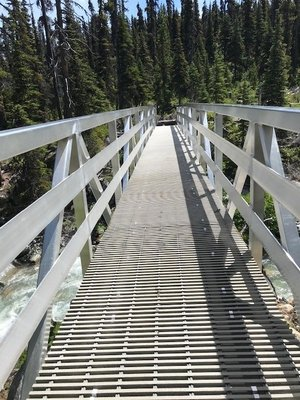

46396__Goat_Creek_Bridge_1.jpg

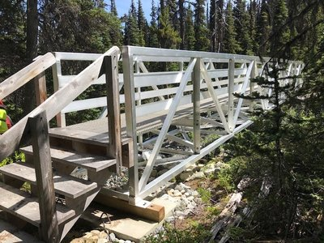

46397__Goat_Creek_Bridge_2.jpg

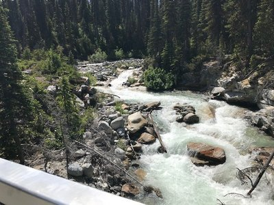

46398__Goat_Creek_Bridge_3.jpg

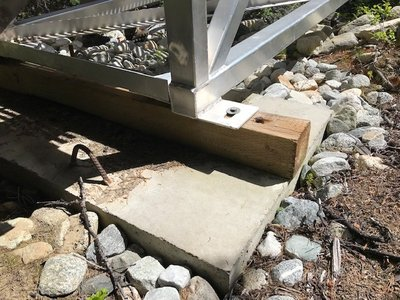

46399__Goat_Creek_Bridge_4.jpg

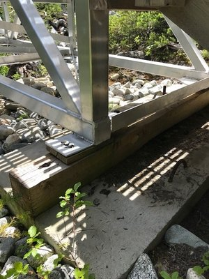

46400__Goat_Creek_Bridge_6.jpg

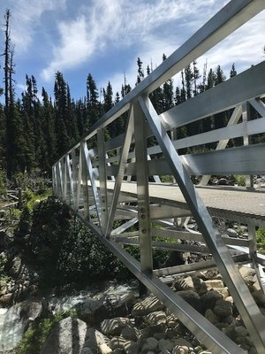

46401__Goat_Creek_Bridge_7.jpg

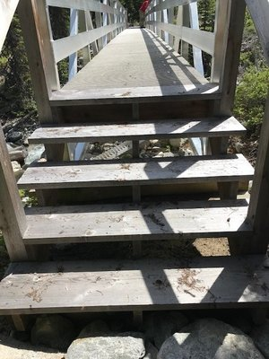

46402__Goat_Creek_Bridge_8.jpg

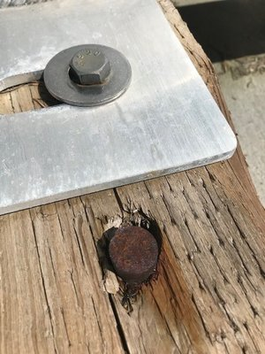

46403__Goat_Creek_Bridge_9.jpg

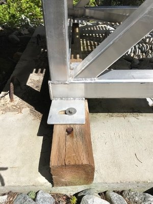

46404__Goat_Creek_5.jpg

Asset 87769 1 image

Predicted: VLM: Beam | DINOv3: Beam (conf: N/A)

Actual: Truss

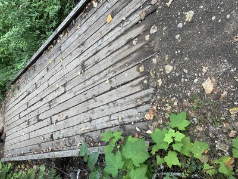

18223__AST_IM_20210823_121751.jpeg

Asset 91832 1 image

Predicted: VLM: Beam | DINOv3: Beam (conf: N/A)

Actual: Truss

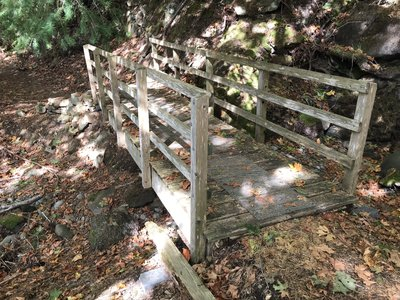

26360__IMG_1112.JPEG

Asset 102849 1 image

Predicted: VLM: Beam | DINOv3: Beam (conf: N/A)

Actual: Truss

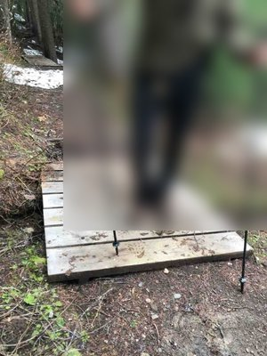

47360__AST_IM_20220617_140540.jpeg

Asset 103256 1 image

Predicted: VLM: Beam | DINOv3: Beam (conf: N/A)

Actual: Truss

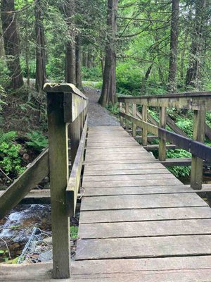

48053__AST_IM_20220620_140345.jpeg

Asset 107885 2 images

Predicted: VLM: Truss | DINOv3: Truss (conf: N/A)

Actual: Beam

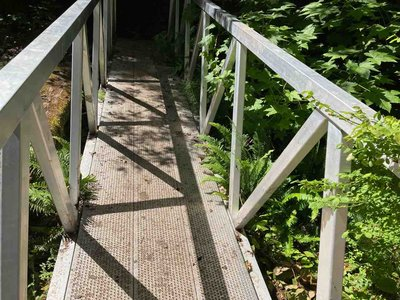

54959__AST_IM_20220720_155827.jpeg

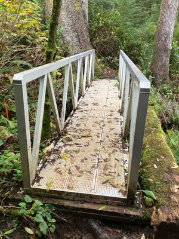

76402__AST_EX_20241025_105426.jpeg

Asset 107973 3 images

Predicted: VLM: Truss | DINOv3: Truss (conf: N/A)

Actual: Beam

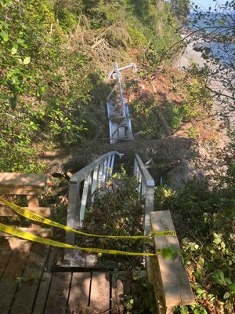

55092__AST_IM_20220720_163218.jpeg

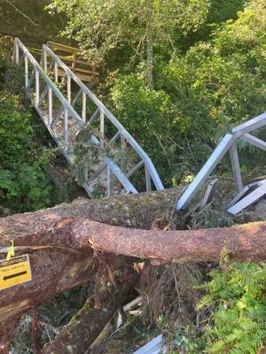

55093__AST_IM_20220720_162852.jpeg

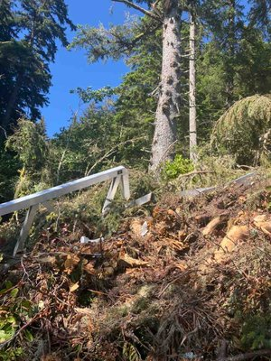

55113__AST_IM_20220720_162859.jpeg

Asset 123310 1 image

Predicted: VLM: Beam | DINOv3: Beam (conf: N/A)

Actual: Fallen Tree

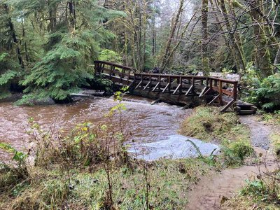

77432__AST_IM_20241113_143720.jpeg

Asset 126199 1 image

Predicted: VLM: Beam | DINOv3: Beam (conf: N/A)

Actual: Truss

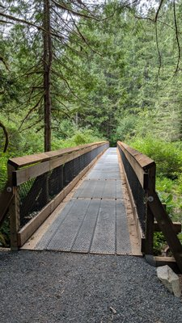

83496__bridge_inland_lake.jpg

Asset 126340 2 images

Predicted: VLM: Truss | DINOv3: Truss (conf: N/A)

Actual: Beam

[figure not shown]

84040__AST_IM_20250616_143933.jpeg

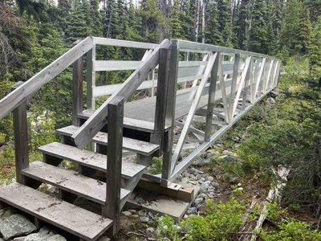

84046__AST_IM_20250616_144043.jpeg

Asset 126709 1 image

Predicted: VLM: Beam | DINOv3: Beam (conf: N/A)

Actual: Other

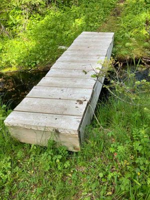

85374__AST_IM_20250723_164003.jpeg

Asset 126915 3 images

Predicted: VLM: Truss | DINOv3: Truss (conf: N/A)

Actual: Beam

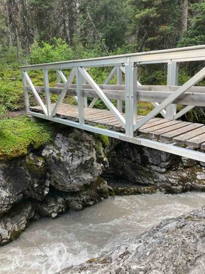

85843__AST_IM_20250730_161027.jpeg

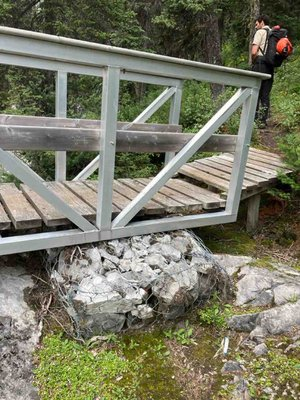

85844__AST_IM_20250730_161039.jpeg

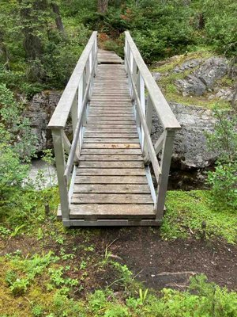

85845__AST_IM_20250730_160958.jpeg

Asset 127136 2 images

Predicted: VLM: Truss | DINOv3: Beam (conf: N/A)

Actual: Other

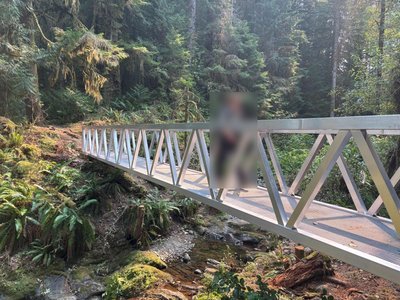

90541__Footpath_bridge_1.jpg

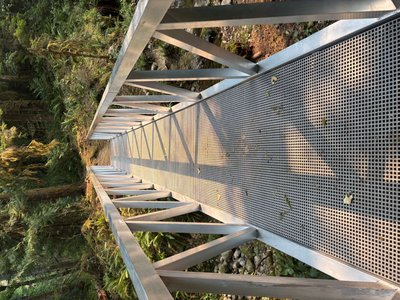

90542__Footpath_bridge_2.jpg

Asset 127147 1 image

Predicted: VLM: Beam | DINOv3: Beam (conf: N/A)

Actual: Other

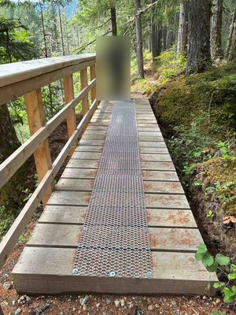

87009__AST_IM_20250819_133749.jpeg

Asset 128273 3 images

Predicted: VLM: Truss | DINOv3: Truss (conf: N/A)

Actual: Other

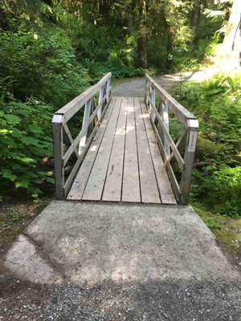

90332__AST_EX_20220617_171132.jpeg

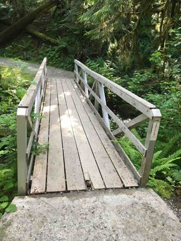

90331__AST_EX_20220617_171114.jpeg

[figure not shown]

90333__AST_EX_20220617_171150.jpeg

Asset 129304 1 image

Predicted: VLM: Beam | DINOv3: Beam (conf: N/A)

Actual: Fallen Tree

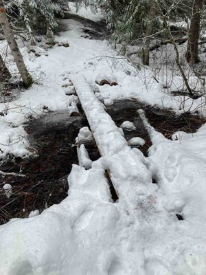

92214__AST_IM_20251211_110345.jpeg